# Signatures of salinity gradients in the chemical composition of proteins (2020)

This vignette runs the code to make the plots from the following paper:

> Dick JM, Yu M, Tan J. 2020. Uncovering chemical signatures of salinity gradients through compositional analysis of protein sequences. *Biogeosciences* **17**(23): 6145–6162. doi: 10.5194/bg-17-6145-2020

This vignette was compiled on 2025-05-20 with **JMDplots** 1.2.22 and **canprot** 2.0.0.

```r
library(JMDplots)
```

The QEC basis species (glutamine, glutamic acid, cysteine, H<sub>2</sub>O, O<sub>2</sub>) are used for the analysis of stoichiometric hydration state (*n*H<sub>2</sub>O).

## Number of reactions for each amino acid in *E. coli* metabolic reconstruction

Reaction equations used for this calculation are from [Feist et al. (2007)](https://doi.org/10.1038/msb4100155).

```r
gradH2O0()
```

```
## Glu Ser Asp Gln Ala Gly Met Cys Thr Arg
##  52  25  23  18  15  15  15  13  12  11
## Lys Asn Pro Trp Val Tyr His Ile Leu Phe
##  10   9   9   8   7   7   6   6   6   5
```

## Comparison of different sets of basis species (Figure 1)

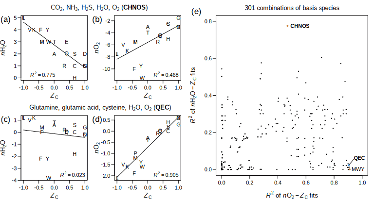

```r
gradH2O1()
```

## Schematic of *n*H<sub>2</sub>O and *Z*<sub>C</sub> calculations (Figure 2)

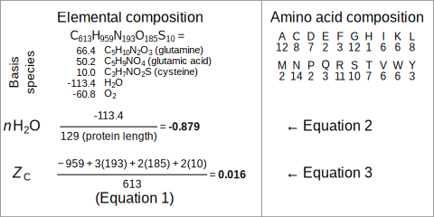

```r
gradH2O2()
```

## *n*H<sub>2</sub>O-*Z*<sub>C</sub> scatterplots for redox gradients and the Baltic Sea (Figure 3)

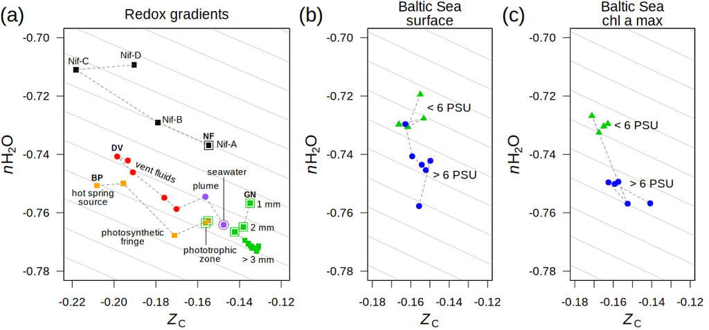

```r
gradH2O3()
```

**Data sources:** Bison Pool (BP; Havig et al., 2011; Swingley et al., 2012); diffuse submarine vents (DV; Reveillaud et al., 2016; Fortunato et al., 2018); Guerrero Negro microbial mat (GN; Kunin et al., 2008); nitrogenase-bearing organisms (NF; Poudel et al., 2018); Baltic Sea (Dupont et al., 2014).

## *n*H<sub>2</sub>O for Baltic Sea metagenome and metatranscriptome in different size fractions (Figure 4)

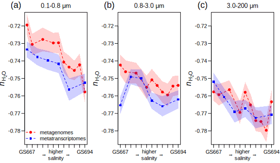

```r
gradH2O4()
```

**Data sources:** metagenome (Dupont et al., 2014) and metatranscriptome (Asplund-Samuelsson et al., 2016).

## *n*H<sub>2</sub>O-*Z*<sub>C</sub> for freshwater, marine, and hypersaline environments (Figure 5)

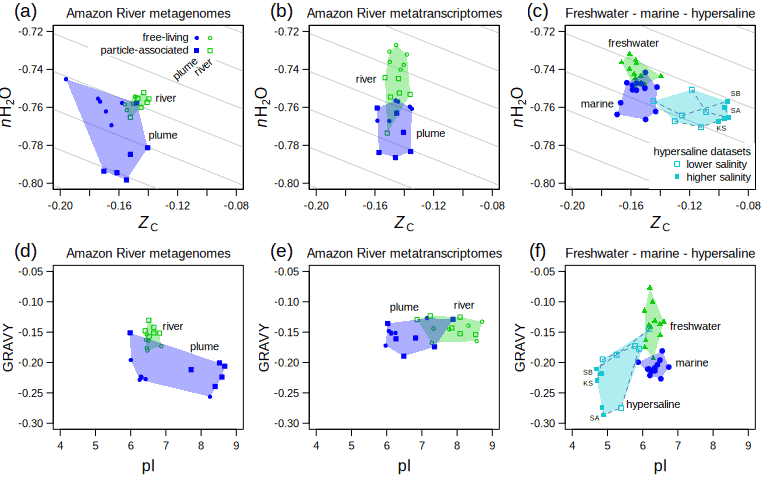

```r
gradH2O5()
```

## *n*H<sub>2</sub>O-*Z*<sub>C</sub> and GRAVY-pI plots for Baltic Sea and Rodriguez-Brito et al. data (Figure 6)

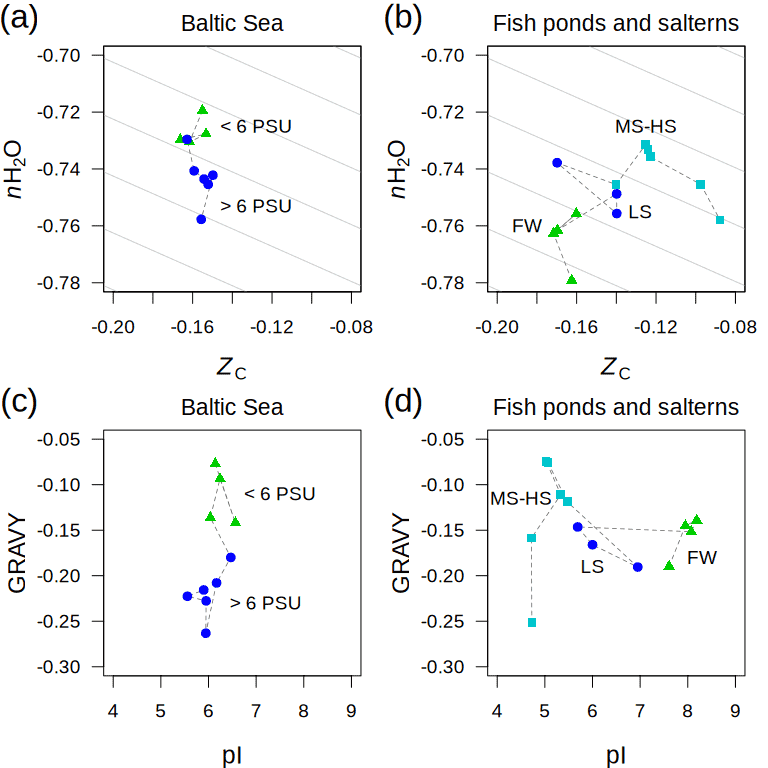

```r
gradH2O6()
```

**Data sources:** Dupont et al. (2014) and Rodriguez-Brito et al. (2010).

## Differential gene and protein expression; time-course experiments and NaCl or organic solutes (Figure 7)

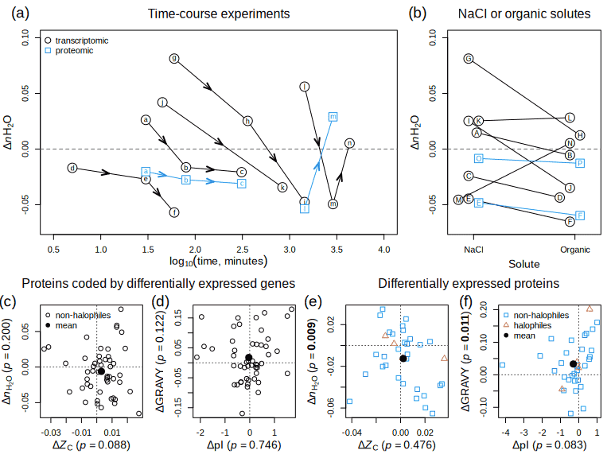

```r
gradH2O7()
```

**Data sources:** *Panel (a):* a–c: Kocharunchitt et al. (2014); d–f: Solheim et al. (2014); g–i: Finn et al. (2015); j–k: Han et al. (2017); l–n: Qiao et al. (2013). *Panel (b):* A–B: Kanesaki et al. (2002); C–D: Han et al. (2005); E–F: Kohler et al. (2015); G–J: Finn et al. (2015); K–L: Shabala et al. (2009); M–N: Withman et al. (2013). *Panels (c) to (f):* See the vignettes `JMDplots::mkvig("osmotic_bact")` and `JMDplots::mkvig("osmotic_halo")`. Links to static vignettes: osmotic_bact and osmotic_halo.

## References

Asplund-Samuelsson J, Sundh J, Dupont CL, Allen AE, McCrow JP, Celepli NA, Bergman B, Ininbergs K, Ekman M. 2016. Diversity and expression of bacterial metacaspases in an aquatic ecosystem. *Frontiers in Microbiology* **7**: 1043. doi: 10.3389/fmicb.2016.01043

Dupont CL, Larsson J, Yooseph S, Ininbergs K, Goll J, Asplund-Samuelsson J, McCrow JP, Celepli N, Allen LZ, Ekman M, et al. 2014. Functional tradeoffs underpin salinity-driven divergence in microbial community composition. *PLOS One* **9**(2): e89549. doi: 10.1371/journal.pone.0089549

Eiler A, Zaremba-Niedzwiedzka K, Martínez-García M, McMahon KD, Stepanauskas R, Andersson SGE, Bertilsson S. 2014. Productivity and salinity structuring of the microplankton revealed by comparative freshwater metagenomics. *Environmental Microbiology* **16**(9): 2682–2698 –. doi: 10.1111/1462-2920.12301

Fernandez AB, Ghai R, Martin-Cuadrado AB, Sanchez-Porro C, Rodriguez-Valera F, Ventosa A. 2013. Metagenome sequencing of prokaryotic microbiota from two hypersaline ponds of a marine saltern in Santa Pola, Spain. *Genome Announcements* **1**(6): e00933–13. doi: 10.1128/genomea.00933-13

Finn S, Rogers L, Händler K, McClure P, Amézquita A, Hinton JCD, Fanning S. 2015. Exposure of *Salmonella enterica* serovar Typhimurium to three humectants used in the food industry induces different osmoadaptation systems. *Applied and Environmental Microbiology* **81**(19): 6800–6811. doi: 10.1128/AEM.01379-15

Fortunato CS, Larson B, Butterfield DA, Huber JA. 2018. Spatially distinct, temporally stable microbial populations mediate biogeochemical cycling at and below the seafloor in hydrothermal vent fluids. *Environmental Microbiology* **20**(2): 769–784. doi: 10.1111/1462-2920.14011

Ghai R, Pašić L, Fernández AB, Martin-Cuadrado A-B, Mizuno CM, McMahon KD, Papke RT, Stepanauskas R, Rodriguez-Brito B, Rohwer F, et al. 2011. New abundant microbial groups in aquatic hypersaline environments. *Scientific Reports* **1**: 135. doi: 10.1038/srep00135

Han D, Link H, Liesack W. 2017. Response of *Methylocystis* sp. Strain SC2 to salt stress: Physiology, global transcriptome, and amino acid profiles. *Applied and Environmental Microbiology* **83**(20): e00866–17. doi: 10.1128/AEM.00866-17

Han Y, Zhou D, Pang X, Zhang L, Song Y, Tong Z, Bao J, Dai E, Wang J, Guo Z, et al. 2005. Comparative transcriptome analysis of *Yersinia pestis* in response to hyperosmotic and high-salinity stress. *Research in Microbiology* **156**(3): 403–415. doi: 10.1016/j.resmic.2004.10.004

Havig JR, Raymond J, Meyer-Dombard DR, Zolotova N, Shock EL. 2011. Merging isotopes and community genomics in a siliceous sinter-depositing hot spring. *Journal of Geophysical Research* **116**: G01005. doi: 10.1029/2010JG001415

Kanesaki Y, Suzuki I, Allakhverdiev SI, Mikami K, Murata N. 2002. Salt stress and hyperosmotic stress regulate the expression of different sets of genes in *Synechocystis* sp. PCC 6803. *Biochemical and Biophysical Research Communications* **290**(1): 339–348. doi: 10.1006/bbrc.2001.6201

Kimbrel JA, Ballor N, Wu Y-W, David MM, Hazen TC, Simmons BA, Singer SW, Jansson JK. 2018. Microbial community structure and functional potential along a hypersaline gradient. *Frontiers in Microbiology* **9**: 1492. doi: 10.3389/fmicb.2018.01492

Kocharunchitt C, King T, Gobius K, Bowman JP, Ross T. 2014. Global genome response of *Escherichia coli* O157:H7 Sakai during dynamic changes in growth kinetics induced by an abrupt downshift in water activity. *PLOS One* **9**(3): e90422. doi: 10.1371/journal.pone.0090422

Kohler C, Lourenço RF, Bernhardt J, Albrecht D, Schüler J, Hecker M, Gomes SL. 2015. A comprehensive genomic, transcriptomic and proteomic analysis of a hyperosmotic stress sensitive *α*-proteobacterium. *BMC Microbiology* **15**: 71. doi: 10.1186/s12866-015-0404-x

Kunin V, Raes J, Harris JK, Spear JR, Walker JJ, Ivanova N, Mering C von, Bebout BM, Pace NR, Bork P, et al. 2008. Millimeter-scale genetic gradients and community-level molecular convergence in a hypersaline microbial mat. *Molecular Systems Biology* **4**: 198. doi: 10.1038/msb.2008.35

Poudel S, Colman DR, Fixen KR, Ledbetter RN, Zheng Y, Pence N, Seefeldt LC, Peters JW, Harwood CS, Boyd ES. 2018. Electron transfer to nitrogenase in different genomic and metabolic backgrounds. *Journal of Bacteriology* **200**(10): e00757–17. doi: 10.1128/JB.00757-17

Qiao J, Huang S, Te R, Wang J, Chen L, Zhang W. 2013. Integrated proteomic and transcriptomic analysis reveals novel genes and regulatory mechanisms involved in salt stress responses in *Synechocystis* sp. PCC 6803. *Applied Microbiology and Biotechnology* **97**(18): 8253–8264. doi: 10.1007/s00253-013-5139-8

Reveillaud J, Reddington E, McDermott J, Algar C, Meyer JL, Sylva S, Seewald J, German CR, Huber JA. 2016. Subseafloor microbial communities in hydrogen-rich vent fluids from hydrothermal systems along the Mid-Cayman Rise. *Environmental Microbiology* **18**(6): 1970–1987. doi: 10.1111/1462-2920.13173

Rodriguez-Brito B, Li L, Wegley L, Furlan M, Angly F, Breitbart M, Buchanan J, Desnues C, Dinsdale E, Edwards R, et al. 2010. Viral and microbial community dynamics in four aquatic environments. *The ISME Journal* **4**: 739–751. doi: 10.1038/ismej.2010.1

Satinsky BM, Fortunato CS, Doherty M, Smith CB, Sharma S, Ward ND, Krusche AV, Yager PL, Richey JE, Moran MA, et al. 2015. Metagenomic and metatranscriptomic inventories of the lower Amazon River, May 2011. *Microbiome* **3**(1): 39. doi: 10.1186/s40168-015-0099-0

Satinsky BM, Zielinski BL, Doherty M, Smith CB, Sharma S, Paul JH, Crump BC, Moran MA. 2014. The Amazon continuum dataset: Quantitative metagenomic and metatranscriptomic inventories of the Amazon River plume, June 2010. *Microbiome* **2**(1): 17. doi: 10.1186/2049-2618-2-17

Shabala L, Bowman J, Brown J, Ross T, McMeekin T, Shabala S. 2009. Ion transport and osmotic adjustment in *Escherichia coli* in response to ionic and non-ionic osmotica. *Environmental Microbiology* **11**(1): 137–148. doi: 10.1111/j.1462-2920.2008.01748.x

Solheim M, La Rosa SL, Mathisen T, Snipen LG, Nes IF, Brede DA. 2014. Transcriptomic and functional analysis of NaCl-induced stress in *Enterococcus faecalis*. *PLOS One* **9**(4): 1–13. doi: 10.1371/journal.pone.0094571

Swingley WD, Meyer-Dombard DR, Shock EL, Alsop EB, Falenski HD, Havig JR, Raymond J. 2012. Coordinating environmental genomics and geochemistry reveals metabolic transitions in a hot spring ecosystem. *PLOS One* **7**(6): e38108. doi: 10.1371/journal.pone.0038108

Vavourakis CD, Ghai R, Rodriguez-Valera F, Sorokin DY, Tringe SG, Hugenholtz P, Muyzer G. 2016. Metagenomic insights into the uncultured diversity and physiology of microbes in four hypersaline soda lake brines. *Frontiers in Microbiology* **7**: 211. doi: 10.3389/fmicb.2016.00211

Withman B, Gunasekera TS, Beesetty P, Agans R, Paliy O. 2013. Transcriptional responses of uropathogenic *Escherichia coli* to increased environmental osmolality caused by salt or urea. *Infection and Immunity* **81**(1): 80–89. doi: 10.1128/IAI.01049-12